# Project 2

# Descriptive Analysis

In this section, we focus on visualize the top 3 countries with the most accumulated Covid new cases since the pandemic. The purpose is to address the severity of the spreading speed and emphasize on the major Covid-impact areas. Before we jump into the major analysis, we would like to provide readers with the basic summarization, including number of new cases, number of death, Infection Fatality Ratio.

Up to Feburary 28th, 2021 Worldwide Level:

- Accumulated New Covid Cases `sum(covid$New_cases)`: 114853685
- Accumulated Death Covid Cases `sum(covid$New_deaths)`: 2554694
- Infection Fatality Ratio (IFR, in %)： 2.224%
- Infection Fatality Ratio (IFR, in %) = Number of deaths from disease / Number of infected individuals * 100

In order to address to what degree a government’s response may associate with Covid-19’s spread, it is prudent to first demonstrate that there are measurable differences in Covid-19’s spread, by country. These differences in Covid-19’s spread are generally known about by the public, and were the biggest source of inspiration for this report.

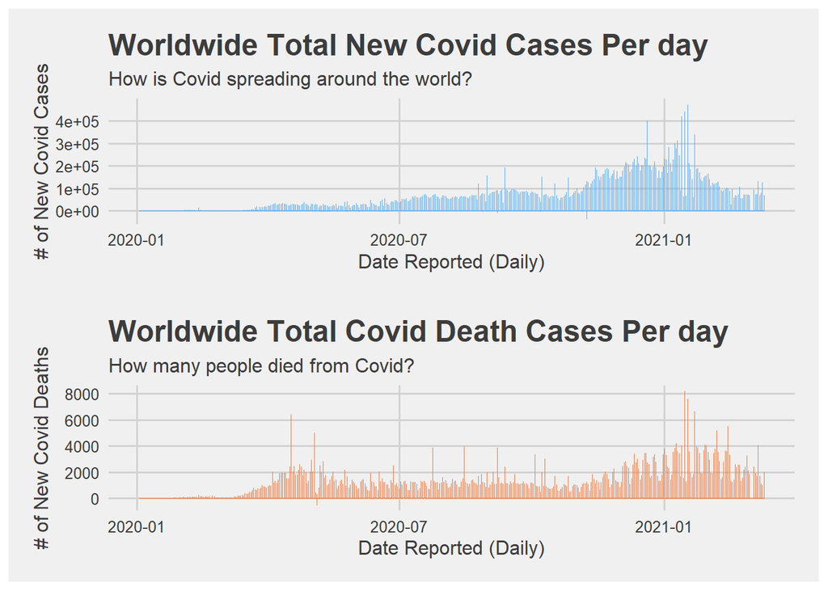

```r
plot1 <- ggplot(data=covid, mapping = aes(x=Date, y=New_cases)) +
  geom_line(color = "steelblue2", size = 0.1) +
  labs(title = "Worldwide Total New Covid Cases Per day",
       subtitle = "How is Covid spreading around the world?",
       x = "Date Reported (Daily)",
       y = "# of New Covid Cases") +
  theme_fivethirtyeight() +
  theme(axis.title = element_text())

plot2 <- ggplot(data=covid, mapping = aes(x=Date, y=New_deaths)) +
  geom_line(color = "sienna2", size = 0.1) +
  labs(title = "Worldwide Total Covid Death Cases Per day",
       subtitle = "How many people died from Covid?",
       x = "Date Reported (Daily)",
       y = "# of New Covid Deaths") +
  theme_fivethirtyeight() +
  theme(axis.title = element_text())

plot1 / plot2 + plot_layout(ncol = 1, heights=c(4,4))
```

The plots above us, give us an idea of how Covid-19 deaths may relate to Covid-19’s spread. Intuitively, we may expect that higher amounts of Covid-19 cases would lead to higher amounts of Covid-19 deaths. However, looking at Worldwide Covid Death Cases per Day, we can see a sharp spike around April and May 2020, where Worldwide New Covid Cases per Day doesn’t seem to indicate a particular spike in cases. How and why can this be? We will take a look at the country of Italy below, which may be a significant source of the spike in deaths.

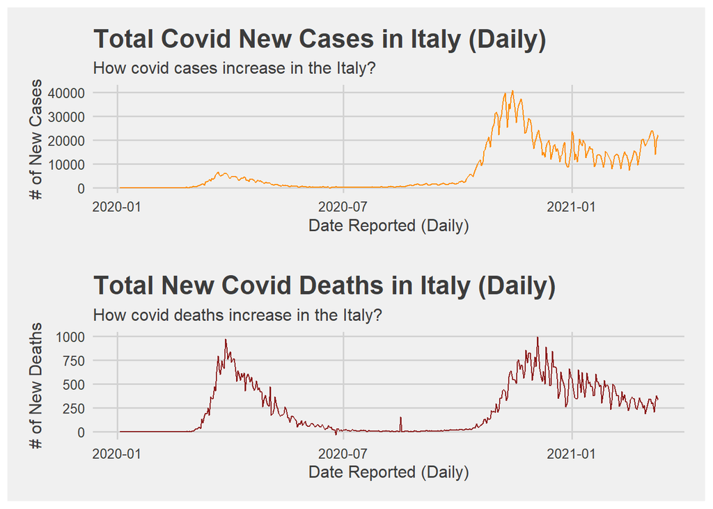

```r
Italy <- covid[covid$Country == "Italy",]

plot_Italy_c <- Italy %>% ggplot(aes(x=Date, y=New_cases)) +
  geom_line(color = "darkorange", size = 0.5)+
   labs(title = "Total Covid New Cases in Italy (Daily)",
       subtitle = "How covid cases increase in the Italy?",
       x = "Date Reported (Daily)",
       y = "# of New Cases") +
  theme_fivethirtyeight() +
  theme(axis.title = element_text())

plot_Italy_d <- Italy %>% ggplot(aes(x=Date, y=New_deaths)) +
  geom_line(color = "firebrick4", size = 0.5)+
   labs(title = "Total New Covid Deaths in Italy (Daily)",
       subtitle = "How covid deaths increase in the Italy?",
       x = "Date Reported (Daily)",
       y = "# of New Deaths",
       color = "Country") +
  theme_fivethirtyeight() +
  theme(axis.title = element_text())


plot_Italy_c / plot_Italy_d + plot_layout(ncol = 1, heights=c(4,4))
```

For a bit of foreshadowing, we can show what the containment index was prior to the sharp spike in deaths in April/May. We can see the containment index was not too high, prior to the spike in cases. To what degree a less adequate response may associate with covid cases, we can’t say definitively yet. This only serves as an interesting example to highlight the portions of the data that may prove significant in testing our question of interest.

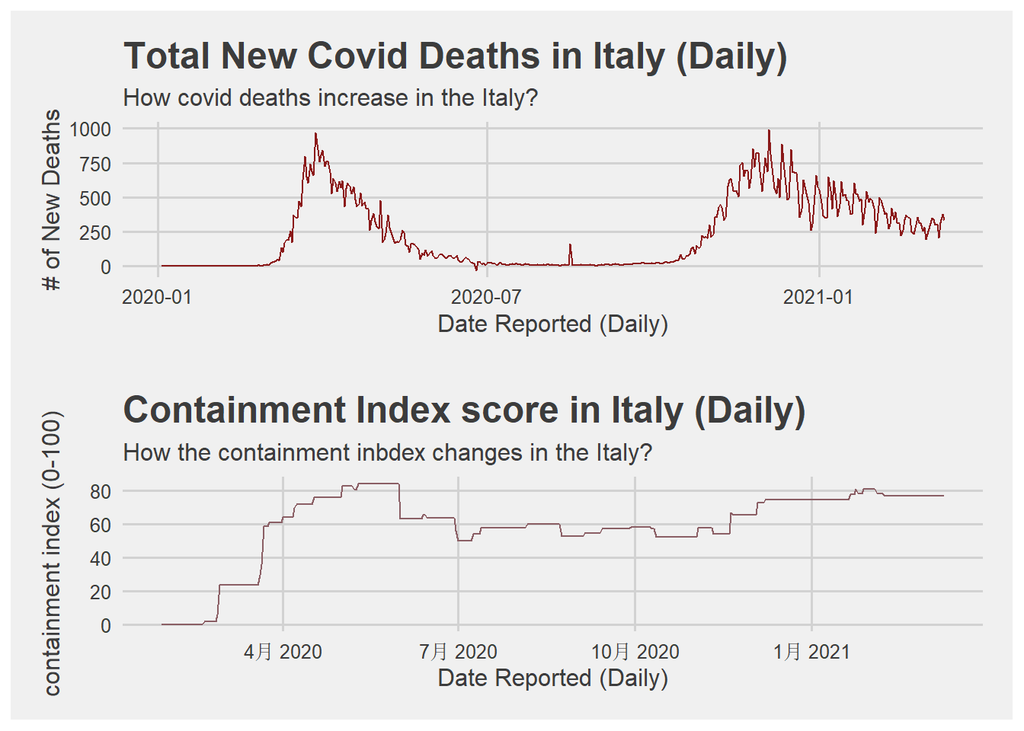

```r
Italy2 <- covid_index[covid_index$Country == "Italy",]

plot_Italy_ci <- Italy2 %>% ggplot(aes(x=Date, y=containment_index)) +
  geom_line(color = "lightpink4", size = 0.5)+
   labs(title = "Containment Index score in Italy (Daily)",
       subtitle = "How the containment inbdex changes in the Italy?",
       x = "Date Reported (Daily)",
       y = "containment index (0-100)") +
  theme_fivethirtyeight() +
  theme(axis.title = element_text())

plot_Italy_d <- Italy %>% ggplot(aes(x=Date, y=New_deaths)) +
  geom_line(color = "firebrick4", size = 0.5)+
   labs(title = "Total New Covid Deaths in Italy (Daily)",
       subtitle = "How covid deaths increase in the Italy?",
       x = "Date Reported (Daily)",
       y = "# of New Deaths") +
  theme_fivethirtyeight() +
  theme(axis.title = element_text())

plot_Italy_d / plot_Italy_ci + plot_layout(ncol = 1, heights=c(4,4))
```

Below, we can see daily Covid-19 reported cases in the 3 countries with the largest amount of cases. We can see spikes and valleys in the plots at different times. In the US, cases spike around Dec. 2020, where in India they might spike around Sept. 2020. This suggests case spikes are due more to localized reasons, and that each country roughly experiences a unique pattern of spread. An obvious question that arises, is to what degree the population size may explain the higher amount of cases. This is a factor to some degree, as the US and India are the third and second largest countries by population respectively, however India has a population roughly 4 times the size of the US population and slightly less total cases than the US. Moreover, China with a population also about 4 times larger than the US, is rank 85 in regards to total Covid-19 cases. Brazil currently has the third highest amount of Covid-19 cases, and is the sixth largest country by population. This means three countries larger in population, have fewer cases, in some cases far fewer cases. All this to suggest, that larger factors such than population size alone, such as government response, may be at play.

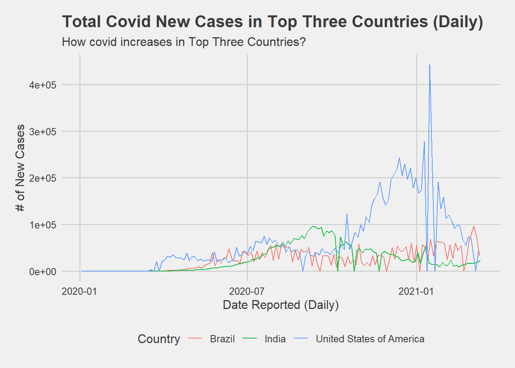

```r
US <- covid[covid$Country == c("United States of America","Brazil","India"),]

plot_top3 <- US %>% ggplot(aes(x=Date, y=New_cases,color = Country)) +
  geom_line(size = 0.5)+
   labs(title = "Total Covid New Cases in Top Three Countries (Daily)",
       subtitle = "How covid increases in Top Three Countries?",
       x = "Date Reported (Daily)",
       y = "# of New Cases") +
  theme(axis.title = element_text()) +
  theme_fivethirtyeight() +
  theme(axis.title = element_text()) +
  theme(plot.title = element_text(size=16))

plot_top3
```

The United States of America, Brazil, and India are the top 3 countries which had accumulated over 10,000,000 Covid diagnosis cases since the beginning of the pandemic. We calculated a total of 114853685 diagnosis Covid cases, and the top three countries contributed to 43.7% of the total world wide new Covid cases. This data could serve as a warning alert for WHO to focus on helping countries with the most cases and upgrade the system of Covid virus detection and prevention.

Based on our primary question of interest, the variables that we are interested in exploring from these two data sets includes `New_cases`, which tracks the number of new cases found in a country each day, and `containment_index`, which measures the stringency of said country’s response to COVID-19. Since we are interested in analyzing these two variables together, we’ll need to merge the two datasets they are found in.

However, before we do so we have to recognize an important fact about how COVID-19 spreads and its potential relationship to government restrictions. COVID-19 infections that are symptomatic and thus the most contagious can last up to four weeks or more. People sick today might not know they are sick until two weeks after they contract the virus and they may infect others for up to several weeks later. This means that any restrictions or response made today is not likely to impact the number of new cases for several weeks. For the purpose of this report we will thus be comparing the number of new cases on any given day with the containment and health index from four weeks prior. This way we can avoid associating government responses with new cases they could not have yet potentially influenced.

We should also take into account another important factor in the spread of COVID-19, population. Countries with larger populations are likely to have more cases, and thus, more new cases per day than smaller countries following similar guidelines. Thus, we should standardize the number of new cases per day for each country by dividing said value by that countries population. Merging our newly created dataset with 2018 population data, we obtain a final dataset that contains not only the number of new cases per day for each country but also each country’s population and containment index. Finally, we will divide the number of new cases per day for each country by that country’s population to get the main variable used for our analysis, `news_cases_div_by_pop`.

The variable `containment_index` has values that range from 0 to 100, with 0 meaning that no restrictions and policies have been put in place and with 100 meaning that the strictest restrictions and policies have been adopted. As of right now this variable is a continuous one. But for the purposes of our project, we want to be able to categorize a country’s stringency as compared to the rest of its peers. Thus, we must first find a set of values we perceive to be representative of the many levels of stringency around the world and then we must transform the `containment_index` variable into a categorical one.

Let us start by first visualizing the distribution of this variable starting at earliest date available to us given the WHO dataset (01/03/2020)

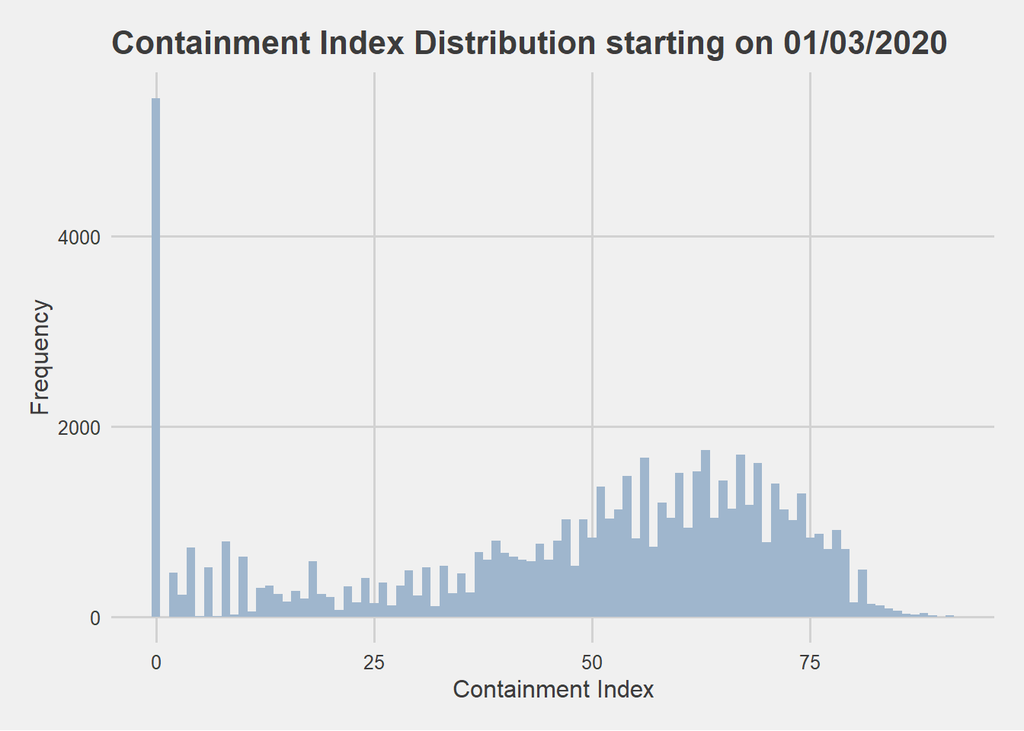

```r
# covid-19 01/03/2020

plot_01_03_2020 <- covid_index_pop %>% ggplot() +
  geom_histogram(mapping = aes(x = containment_index), fill = "slategray3", size = 0.5, binwidth = 1)+
   labs(title = "Containment Index Distribution starting on 01/03/2020",
       x = "Containment Index",
       y = "Frequency") +
  theme_fivethirtyeight() +
  theme(axis.title = element_text()) +
  theme(plot.title = element_text(size=16))
plot_01_03_2020
```

As we can see from above, there is one value that stands out starkly from the rest, 0. Now this could be because many countries simply chose not to respond to COVID throughout the pandemic or it could be because of the dates we chose to start at. On 01/03/2020, COVID-19 was not yet considered a global threat and so it makes sense that for most countries zero restrictions and policies would be in place. To confirm this theory, lets take a look at how the distribution changes when only values after 01/30/2020 are considered (01/30/2020 is the day the WHO announced COVID-19 was of global concern).

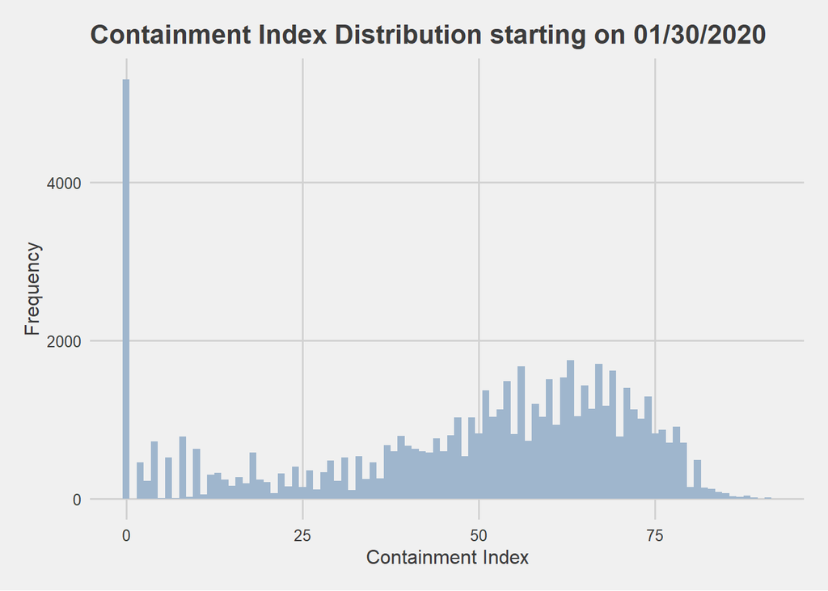

```r
plot_01_30_2020 <- covid_post_0130 %>% ggplot() +
  geom_histogram(mapping = aes(x = containment_index), fill = "slategray3", size = 0.5, binwidth = 1)+
   labs(title = "Containment Index Distribution starting on 01/30/2020",
       x = "Containment Index",
       y = "Frequency") +
  theme_fivethirtyeight() +
  theme(axis.title = element_text()) +
  theme(plot.title = element_text(size=16))
plot_01_30_2020
```

The distribution above has not changed much at all and a containment index of 0 still stands out starkly from the rest. Perhaps the first theory mentioned above is correct and many governments have just not responded to COVID-19. However, we should keep in mind that on 01/30/2020, there were only roughly 6,102 cases worldwide with the majority being in China. It is possible that due to a lack of domestic cases, many countries had not yet started paying attention to COVID-19. For these reasons, let’s take a look at an even later date, 03/11/2020, the day COVID-19 was declared a global pandemic by the WHO. The containment index distribution taken after from that date onward is as follows:

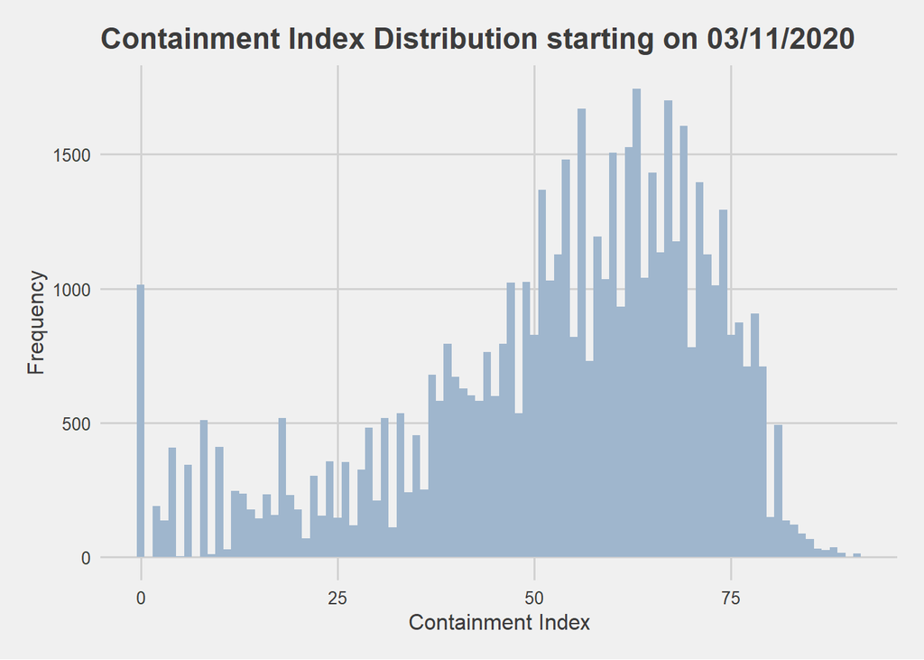

```r
plot_03_11_2020 <- covid_post_0311 %>% ggplot() +
  geom_histogram(mapping = aes(x = containment_index), fill = "slategray3", size = 0.5, binwidth = 1)+
   labs(title = "Containment Index Distribution starting on 03/11/2020",
       x = "Containment Index",
       y = "Frequency") +
  theme_fivethirtyeight() +
  theme(axis.title = element_text()) +
  theme(plot.title = element_text(size=16))
plot_03_11_2020
```

As we can see the number of 0 index values has fallen sharply by 03/11/2020. This means that following the announcement of COVID-19 as a global pandemic, most countries had started responding to it, imposing restrictions and policies designed to combat its spread. In fact, we can see in the below graph that the vast majority of countries before this date largely did nothing to address the virus.

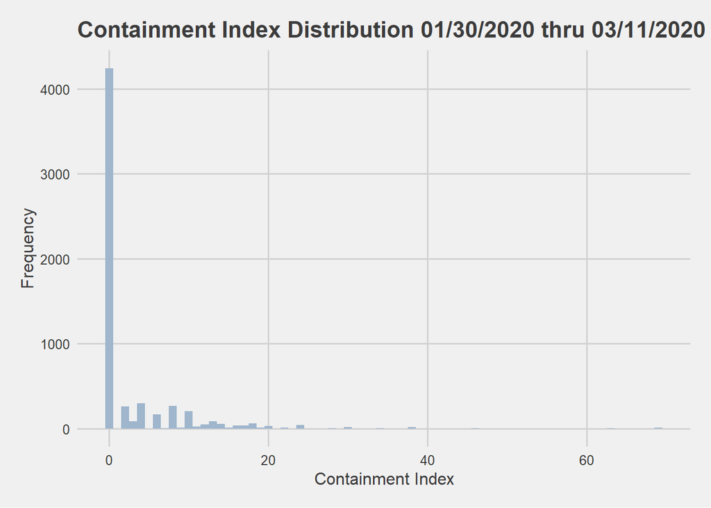

```r
# Plot for ^^
plot_01_30_thru_03_11_2020 <- covid_post_01300310 %>% ggplot() +
  geom_histogram(mapping = aes(x = containment_index), fill = "slategray3", size = 0.5, binwidth = 1)+
   labs(title = "Containment Index Distribution 01/30/2020 thru 03/11/2020",
       x = "Containment Index",
       y = "Frequency") +
  theme_fivethirtyeight() +
  theme(axis.title = element_text()) +
  theme(plot.title = element_text(size=16))
plot_01_30_thru_03_11_2020
```

With all that being said, using the containment index distribution sourced from dates after the announcement is more likely to be better representative of how governments actually responded to this pandemic (again, before this date, it technically was not a pandemic yet). Seeing as we want to split the data into relatively equal parts, percentiles are likely the best possible choice in this case. Listed below are the percentile values for the 20th, 40th, 60th, and 80th percentiles.

```r
#Lenient, Lenient-Moderate, Moderate, Strict-Moderate, Strict

quantile(covid_post_0311$containment_index, c(0.2, 0.4, 0.6, 0.8))
```

```
##   20%   40%   60%   80%
## 38.46 51.92 61.54 69.23
```

Categorizing the containment index by these values we end up with 5 different levels and a new variable called `containment_index_leveled`.

- For containment index values from 0 to 38.46, countries are labeled as being lenient (Lenient) in their responses.
- For containment index values from 38.46 to 51.92, countries are labeled as being moderately lenient (Lenient_Mod) in their responses.
- For containment index values from 51.92 to 61.54, countries are labeled as being moderate (Moderate) in their responses.
- For containment index values from 61.54 to 69.23, countries are labeled as being moderately strict (Mod_Strict) in their responses.
- For containment index values from 69.23 to 100, countries are labeled as being strict (Strict) in their responses.

With `containment_index` transformed into a categorical variable, we can go on to analyze its relationship to new cases using a two way ANOVA model.

# Inferential Analysis

In order to assess if there is in fact a correlation between a country’s COVID-19 response and the spread of COVID-19, we will construct a two way ANOVA model. ANOVA models are specifically designed to test the influence of a categorical variable, in this case the leveled containment index, on a continuous one, the number of new COVID-19 cases. While this makes ANOVA modeling quite useful, several assumptions need to be made before using these models.

Finally, we can begin constructing the following ANOVA model. The null hypothesis for this model, in layman’s terms, is that containment index level, regardless of what it is, is not correlated with a change in the number of new COVID-19 cases. The alternative hypothesis, on the other hand, states that at least one containment index level is indeed correlated with changes to a country’s number of new COVID-19 cases.

```r
two_way_anova <- aov(new_cases_div_by_pop~containment_index_leveled+Country, data = covid_index_pop)
summary(two_way_anova)
```

```
##                              Df    Sum Sq   Mean Sq F value Pr(>F)
## containment_index_leveled     4 0.0000564 1.409e-05  743.07 <2e-16 ***
## Country                     150 0.0002750 1.834e-06   96.66 <2e-16 ***
## Residuals                 61118 0.0011593 1.900e-08
## ---
## Signif. codes:  0 '***' 0.001 '**' 0.01 '*' 0.05 '.' 0.1 ' ' 1
```

```r
TukeyHSD(two_way_anova, "containment_index_leveled")
```

```
##   Tukey multiple comparisons of means
##     95% family-wise confidence level
##
## Fit: aov(formula = new_cases_div_by_pop ~ containment_index_leveled + Country, data = covid_index_pop)
##
## $containment_index_leveled
##                                 diff           lwr           upr     p adj
## Lenient_Mod-Lenient     5.649075e-05  5.192082e-05  6.106068e-05 0.0000000
## Moderate-Lenient        7.540212e-05  7.085629e-05  7.994796e-05 0.0000000
## Mod_Strict-Lenient      6.966684e-05  6.505383e-05  7.427984e-05 0.0000000
## Strict-Lenient          6.202002e-05  5.742254e-05  6.661751e-05 0.0000000
## Moderate-Lenient_Mod    1.891137e-05  1.388304e-05  2.393970e-05 0.0000000
## Mod_Strict-Lenient_Mod  1.317608e-05  8.086946e-06  1.826522e-05 0.0000000
## Strict-Lenient_Mod      5.529273e-06  4.541983e-07  1.060435e-05 0.0246872
## Mod_Strict-Moderate    -5.735289e-06 -1.080280e-05 -6.677783e-07 0.0172657
## Strict-Moderate        -1.338210e-05 -1.843549e-05 -8.328713e-06 0.0000000
## Strict-Mod_Strict      -7.646811e-06 -1.276071e-05 -2.532914e-06 0.0004351
```

At a 95% confidence level we see that there are statistically significant differences between the following containment levels in terms of their associated changes in the number of new COVID-19 cases per day.

- Lenient with Lenient-Moderate, Moderate, Moderate-Strict, and Strict
- Lenient-Moderate with Moderate, Moderate-Strict, and Strict
- Moderate with Moderate-Strict and Strict
- Moderate-Strict with Strict

# Sensitivity Test

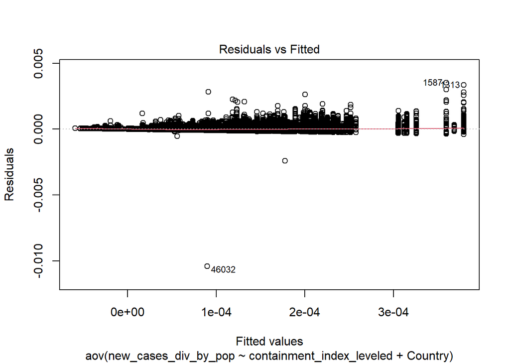

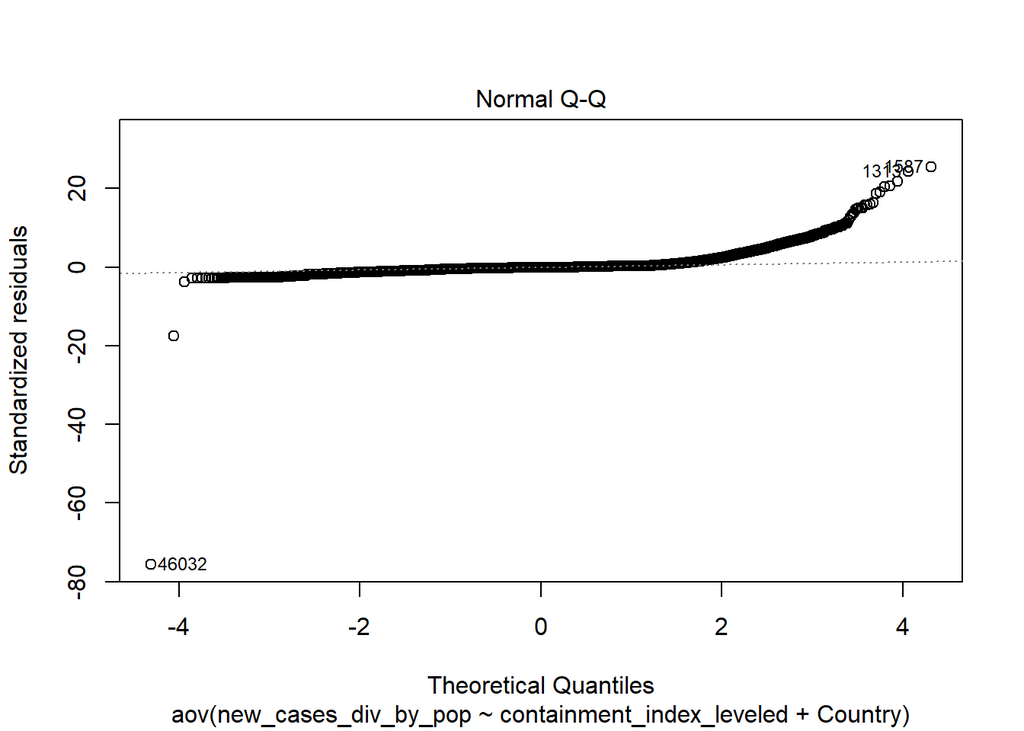

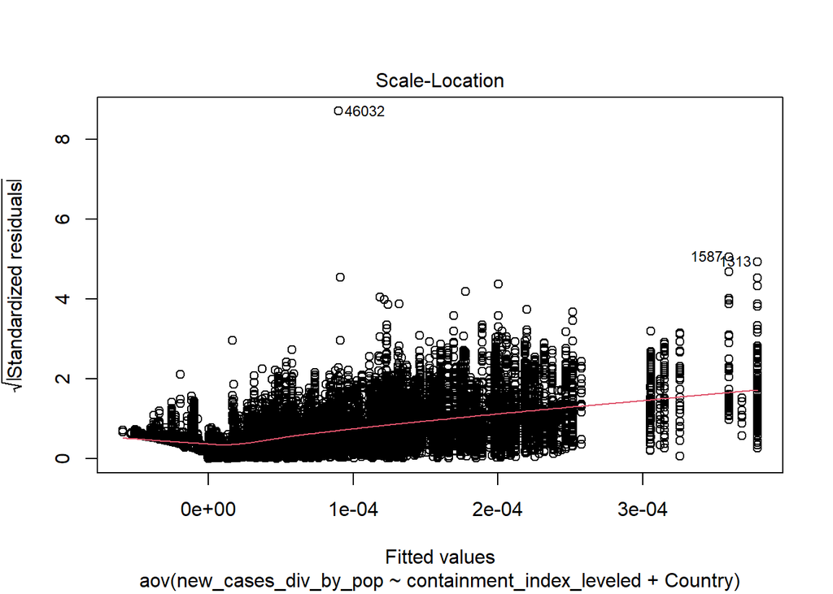

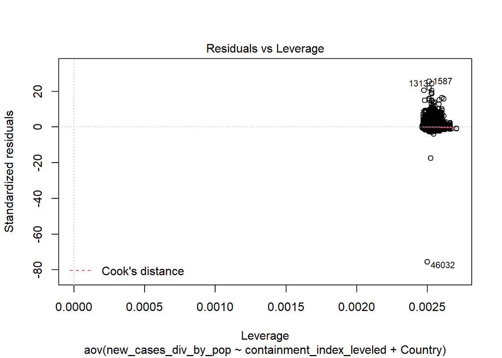

```r
plot(two_way_anova)
```

## Residuals verse Fitted Plot

Based on the plot, we noticed the residual values majorly fall above the 0 line. This suggest that the assumption which the relationship is linear is not reasonable. The spreading pattern had also suggested non-equal variance of the error terms and existing outliers. Thus, the plot seems to indicate a non-linear model and dependency between the residuals and the fitted values. The absolute value of the residuals is strongly positively correlated with the fitted values. The data points formatted in parallel lines due to the containment index levels are categorical variables.

## Normal Q-Q Plot

The Q-Q plot indicates the residuals deviate from the diagonal line mostly in the upper tail as the points form a steeper shape pattern. We concluded that the tail is heavier and contains larger values than what suggests under the standard modeling assumption. Since the residuals appear to be larger in magnitude than expected from the normal distribution, it tells us that the model might fail to comprehensively incorporate the full variability of the given data. The p-value and CI are too optimistic. Since we assume 95% CI and the associated z-value is 1.64, we notice lots of points fall under the z-value on x-axis. However, it is not accurate to conclude that we are 95% confident that our dataset is normally distributed since plenty of points fall outside of the range.

## Scale-Location Plot

The plot shows that the residuals are not spread equally. The red smooth line is steep and could be caused by the wider spread of point #46032. Scale-Location plot checks if the model violate the assumption of equal variance. Since we didn’t see equally spreading points around the red smooth line. It violates the assumption.

# Discussion

Having identified these findings, I believe that there need to be more studies to be able to answer this question as preventing a spread is still quite difficult for most of the world. COVID-19 has taken many lives and while with the vaccinations that are currently being given, we’re on the path to preventing it, we still need to do our best to make sure we figure out the best way to prevent the spread.

# Acknowledgements

This report was put together with the members of Project Group 11, and facets of it were discussed with other students publicly in Piazza. Specifically, we had another user help us with an issue we were having merging our data frames.

It was constructed with the knowledge we have gathered throughout this course: various discussion sections, homework assignments, and class lectures. All instances of the lectures, especially those relating directly to the subject of this report, were of special use. The instruction and guideline for Project 1 was a good foundation point, although we deviated from that structure in minor ways.

# References

Thomas Hale, Sam Webster, Anna Petherick, Toby Phillips, and Beatriz Kira (2020). Oxford COVID-19 Government Response Tracker, Blavatnik School of Government. Retrieved March 04, 2021, https://covidtracker.bsg.ox.ac.uk/

World Bank, World Development Indicators. Available online: https://data.worldbank.org/indicator/SP.POP.TOTL (last cited: [March 4th 2021])

World Health Organization Coronavirus (COVID-19) Dashboard Geneva: World Health Organization, 2020. Available online: https://covid19.who.int/ (last cited: [March 4th 2021])